# Patterns of occurrence

Supplementary Infomation for the paper:

Dr. Shai Pilosof, Ecological Complexity Lab www.bgu.ac.il/ecomplab, Ben Gurion University, Israel

2022-03

```r
# Includes ------------
library(tidyverse)
library(magrittr)
library(cowplot)
library(reshape2)
library(vegan)
library(igraph)
library(GUniFrac)
source('functions.R')

# Load data --------------------------------
ASV_Core_30 <- read_csv('local_output/core_ASV_30.csv') %>%
  mutate(Farm=factor(Farm, levels = c("UK1","UK2","IT1","IT2","IT3","FI1",'SE1')))
```

# About

This file contains the code and resulting plots that describe the patterns of ASV richness and occurrence in farms.

# ASV Richness and diversity

```r
## Richness per cow  --------------------------------
plt_richness_per_cow <-
ASV_Core_30 %>%
  group_by(Cow_Code) %>%
  summarise(Richness=n_distinct(ASV_ID)) %>%
  arrange(desc(Richness)) %>%
  ggplot(aes(Richness))+
  geom_histogram(fill='dark green', color='white')+
  labs(x='ASVs per cow', y='Count') +
  html_figs_theme_no_legend

## Richness per farm  --------------------------------
richness_per_farm <- ASV_Core_30 %>%
  group_by(Farm) %>%
  summarise(ASV_Richness=n_distinct(ASV_ID))

plt_richness_per_farm <-
  richness_per_farm %>%
  arrange(desc(ASV_Richness)) %>%
  ggplot(aes(Farm,ASV_Richness))+
  geom_col(fill='dark red', color='white')+
  theme_classic() +
  labs(y='Number of ASVs') +
  html_figs_theme_no_legend



## Richness per cow per farm   --------------------------------
Richness_per_cow_farm <-
ASV_Core_30 %>%
  group_by(Farm,Cow_Code) %>%
  summarise(S_cow=n_distinct(ASV_ID)) %>%
  group_by(Farm) %>%
  summarise(S_mean=round(mean(S_cow),1),
            S_median=round(median(S_cow),1),
            S_sd=round(sd(S_cow),1),
            S_min=min(S_cow),
            S_max=max(S_cow)) %>%
  mutate(ASV_summary=paste(S_mean,' [',S_min,'-',S_max,']',sep=''))

plt_richness_per_cow_farm <-
ASV_Core_30 %>%
  group_by(Country,Farm,Cow_Code) %>%
  summarise(richness=n_distinct(ASV_ID)) %>%
  arrange(desc(richness)) %>%
  ggplot(aes(x=Farm, y=richness, Country))+
  geom_boxplot(aes(color=Country))+
  theme_bw() +
  labs(y = 'ASV richness per cow per farm') +
  html_figs_theme_no_legend
```

## Fig. S1: Richness per cow

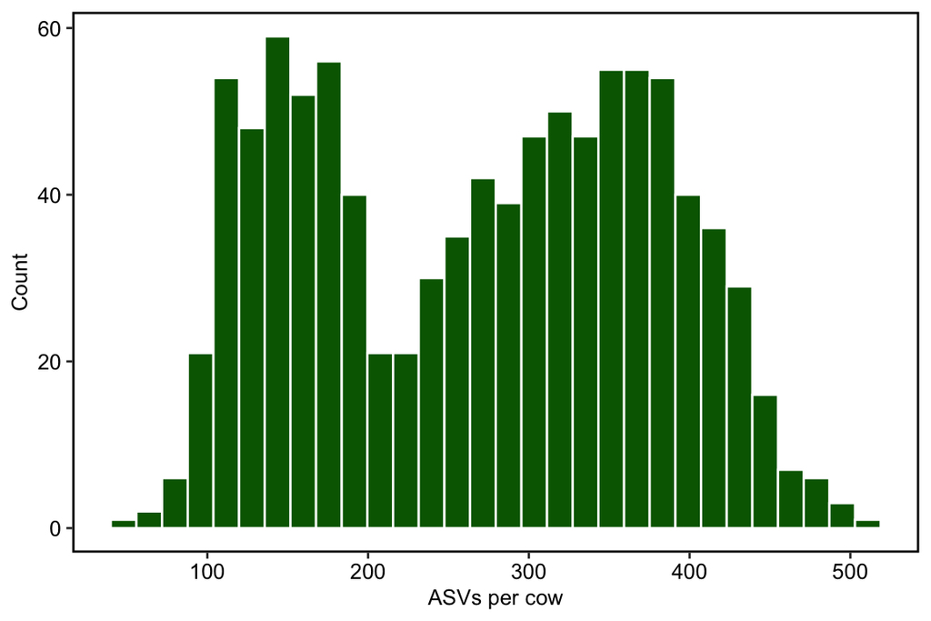

A histogram showing the number of ASVs per cow (across farms).

```r
plt_richness_per_cow
```

```r
# Make a file
pdf('~/Dropbox (BGU)/Apps/Overleaf/Rumen microbiome coocurrence/SI_richness_per_cow.pdf', 10, 6)
plt_richness_per_cow
dev.off()
```

## Fig. S2: Richness per farm

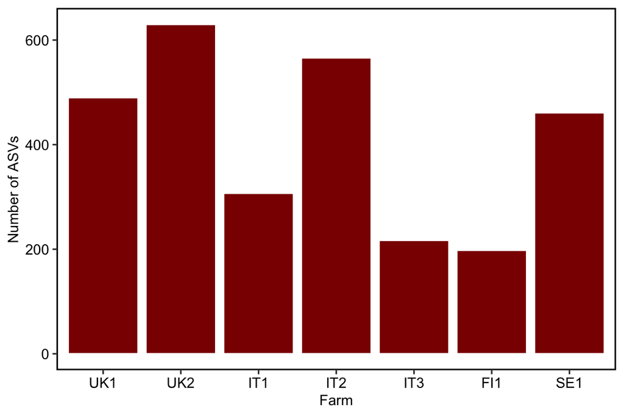

Bar plots of the number of ASVs per farm (across cows).

```r
plt_richness_per_farm
```

```r
# # Make a file
# pdf('~/Dropbox (BGU)/Apps/Overleaf/Rumen microbiome coocurrence/SI_richness_per_farm.pdf', 10, 6)
# plt_richness_per_farm
# dev.off()


# Make a file
pdf('~/Dropbox (BGU)/Apps/Overleaf/Rumen microbiome coocurrence/SI_ASV_richness.pdf', 10, 6)
plot_grid(plt_richness_per_cow,plt_richness_per_farm, ncol=2, rel_widths = c(0.5,0.5), labels = c('(A)','(B)'))
dev.off()
```

## Fig. S3: Richness per cow within farms

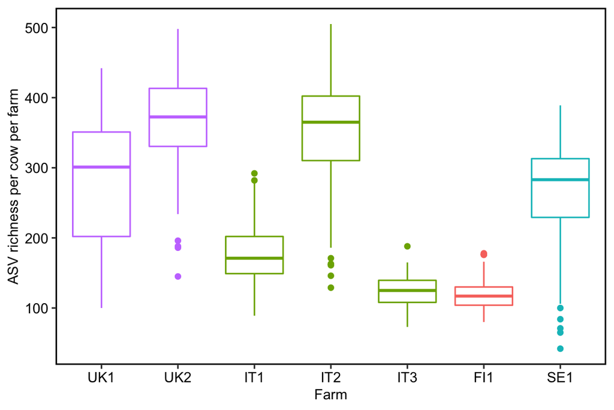

Box plots of the distribution of number of ASVs in cows, within each farm. Colors depict countries.

```r
plt_richness_per_cow_farm
```

```r
# Make a file
pdf('~/Dropbox (BGU)/Apps/Overleaf/Rumen microbiome coocurrence/SI_richness_per_cow_farm.pdf', 10, 6)
plt_richness_per_cow_farm
dev.off()
```

## Fig. S4: ASV Beta diversity between farms

```r
# ASV Beta diversity between farms ----------------
ASV_occurrence_farm <-
  ASV_Core_30 %>%
  select(-c(Cow_Code)) %>%
  distinct(Farm, ASV_ID) %>%
  mutate(present=1) %>%
  spread(ASV_ID, present, fill = 0) %>%
  column_to_rownames("Farm")

## Using Jaccard ----
beta_diver_farms <- as.matrix(1-vegdist(ASV_occurrence_farm, "jaccard"))
diag(beta_diver_farms) <- 1
# Heatmap
beta_diver_farms[lower.tri(beta_diver_farms, diag = F)] <- NA
beta_diver_farms_m <- reshape2::melt(beta_diver_farms)

plt_J <- ggplot(beta_diver_farms_m, aes(x = Var1, y = Var2, fill = value, label=round(value,2))) +
  geom_tile() +
  geom_text(color = "black", size = 4)+
  scale_y_discrete(limits=rev)+
  scale_fill_gradient(high = "blue", low = "light blue", na.value = 'white') +
  html_figs_theme_no_legend+theme(axis.title = element_blank())

## Using UniFrac ----
phylo_tree <- readRDS("local_output/fitted_asvs_phylo_tree.rds")
tree <- phylo_tree$tree
# prune the tree
included_asvs <- unique(ASV_Core_30$ASV_ID)
unincluded <- tree$tip.label[!tree$tip.label %in% included_asvs]
pruned <- dendextend::prune(tree, unincluded)
unifracs <- GUniFrac(ASV_occurrence_farm, pruned, alpha=c(0, 0.5, 1))$unifracs
d_UW <- 1-(unifracs[, , "d_UW"])
# Heatmap
d_UW[lower.tri(d_UW)] <- NA
beta_diver_farms_UF <- reshape2::melt(d_UW)
plt_U <-
ggplot(beta_diver_farms_UF, aes(x = Var1, y = Var2, fill = value, label=round(value,2))) +
  geom_tile() +
  geom_text(color = "black", size = 4)+
  scale_y_discrete(limits=rev)+
  scale_fill_gradient(high = "#ff8c00", low = "#fff494", na.value = 'white') +
  html_figs_theme_no_legend+theme(axis.title = element_blank())

# # Network representation
# beta_div_net <- igraph::graph.adjacency(beta_diver_farms, mode = 'undirected', diag = F, weighted = T)
# E(beta_div_net)$weight
# V(beta_div_net)$color <- c('blue', 'red', 'red', 'red', 'yellow', 'gray','gray')
# num_ASV <- ASV_data %>%
#   group_by(Farm) %>%
#   summarise(ASV_num=n_distinct(ASV_ID))
# V(beta_div_net)$num_ASV <- num_ASV$ASV_num
#
# # pdf('output/figures/beta_div_network.pdf',6,6)
# pdf('~/Dropbox (BGU)/Apps/Overleaf/Rumen microbiome coocurrence/beta_div_network.pdf', 6, 6)
# plot(beta_div_net, edge.width=E(beta_div_net)$weight*10, edge.color='black', layout=layout.circle,
#      vertex.size=V(beta_div_net)$num_ASV/40+20)
# dev.off()

# combine the two plots of beta diversity
# png(filename = 'local_output/figures/beta_diversity_unif_jacc.png', width = 2000, height = 900, res = 300)
plt_beta_div <- plot_grid(plt_J,plt_U, labels = c('(A)','(B)'))
# dev.off()
```

Using Jaccard (A) and UniFrac (B)

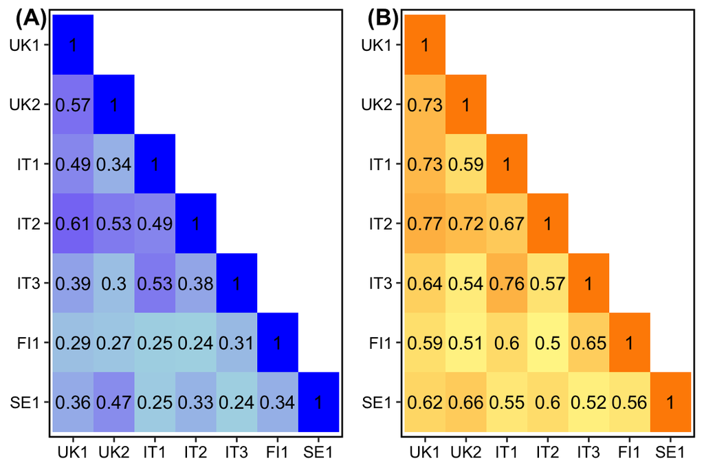

```r
plt_beta_div
```

```r
# Make a file
pdf('~/Dropbox (BGU)/Apps/Overleaf/Rumen microbiome coocurrence/SI_betadiv.pdf', 10, 6)
plt_beta_div
dev.off()
```

# Taxonony

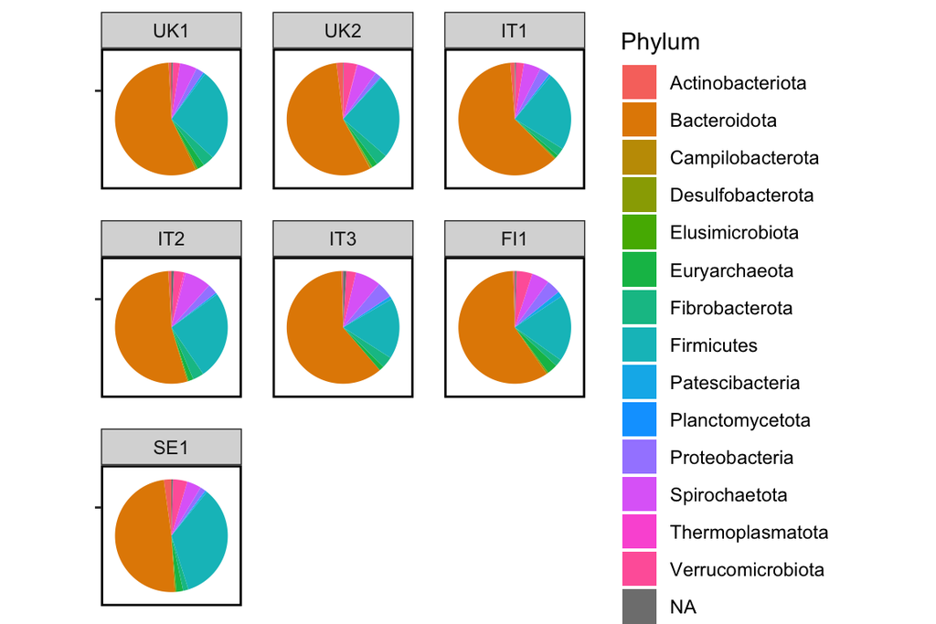

```r
ASV_taxa <-
  read_csv('local_output/ASV_full_taxa.csv') %>% select(ASV_ID, everything(), -seq16S)

phylum_in_farms <-
ASV_Core_30 %>%
  left_join(ASV_taxa) %>%
  group_by(Farm, Phylum) %>%
  summarise(ASV_num=n_distinct(ASV_ID)) %>%
  mutate(relative_richness=ASV_num/sum(ASV_num)) %>%
  mutate(ypos = cumsum(relative_richness)- 0.5*relative_richness) %>%
  ggplot(aes(x="", y=relative_richness, fill=Phylum))+
  facet_wrap(~Farm)+
  geom_bar(stat="identity", width=1) +
  coord_polar("y", start=0)+
  paper_figs_theme+
  theme(axis.text = element_blank(),
        axis.title = element_blank())

phylum_in_farms
```

```r
# Make a file
pdf('~/Dropbox (BGU)/Apps/Overleaf/Rumen microbiome coocurrence/SI_phylum_in_farms.pdf', 10, 6)
phylum_in_farms
dev.off()
```

# Multilayer network and modularity

## Fig. S5: Distribution of link weights

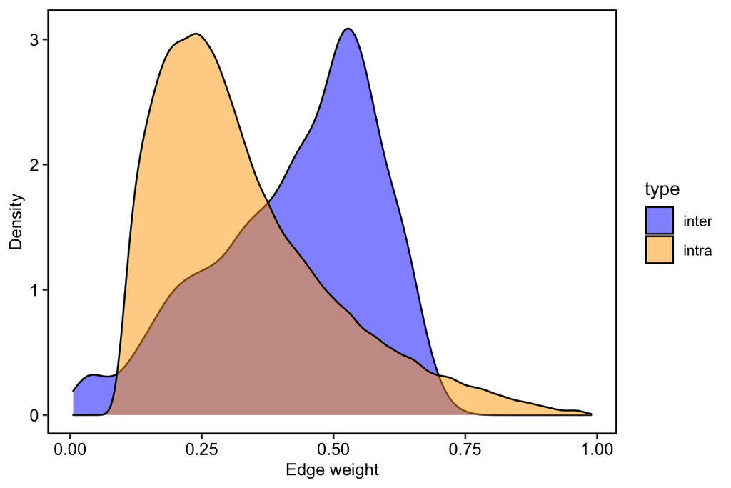

```r
multilayer_unif <- read_csv('local_output/multilayer_unif.csv')

link_weight_distributions <-
ggplot(multilayer_unif, aes(weight, fill=type))+
  geom_density(alpha=0.5)+
  labs(x='Edge weight', y='Density')+
  scale_fill_manual(values = c('blue','orange'))+
 html_figs_theme

link_weight_distributions
```

```r
# Make a file
pdf('~/Dropbox (BGU)/Apps/Overleaf/Rumen microbiome coocurrence/SI_link_weight_distributions.pdf', 10, 6)
link_weight_distributions
dev.off()
```

```r
# Read from files if already run
modules_obs <- read_csv('local_output/farm_modules_pos_30_U_multilevel.csv')
mod_summary_obs <- read_csv('local_output/farm_modules_pos_30_summary.csv', col_names = c('net', 'call', 'L', 'top_modules', 'time_stamp'))
num_modules_obs <- mod_summary_obs$top_modules
L_obs <- mod_summary_obs$L

module_rel_size <-
modules_obs %>%
  mutate(short_name=factor(short_name, levels = c("UK1","UK2","IT1","IT2","IT3","FI1",'SE1'))) %>%
  group_by(short_name) %>%
  mutate(nodes_in_layers=n_distinct(node_id)) %>%
  group_by(short_name,level1) %>%
  mutate(nodes_in_modules=n_distinct(node_id)) %>%
  mutate(nodes_percent=nodes_in_modules/nodes_in_layers) %>%
  distinct(short_name, level1, nodes_percent) %>%
  arrange(level1, short_name)
```

We first observe that there are modules in farms that contain a negligible proportion of all the ndoes in the farms. For instance, in FI1 there are three modules, two of which hold less than 3% of the microbes. Because these modules introduce noise we only include modules that contain 3% or more of the microbes in the farm.

## Fig. S6: Top-modules

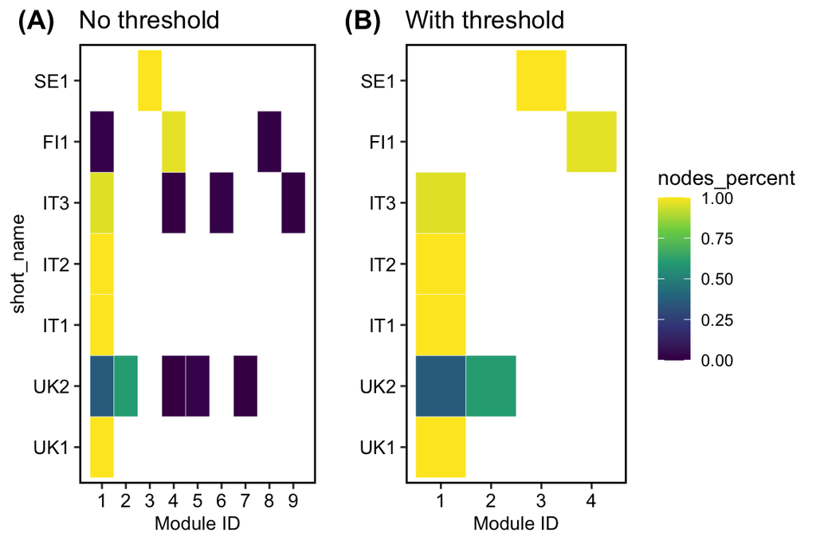

```r
all_modules <-
module_rel_size %>%
  ggplot(aes(x = level1, y = short_name, fill=nodes_percent))+
  geom_tile(color='white')+
  scale_x_continuous(breaks = seq(1, max(modules_obs$level1), 1))+
  scale_fill_viridis_c(limits = c(0, 1))+
  labs(x='Module ID', title='No threshold')+
  html_figs_theme_no_legend

filtered_modules <-
module_rel_size %>%
  filter(nodes_percent>=0.03) %>%
  ggplot(aes(x = level1, y = short_name, fill=nodes_percent))+
  geom_tile(color='white')+
  scale_x_continuous(breaks = seq(1, max(modules_obs$level1), 1))+
  scale_fill_viridis_c(limits = c(0, 1))+
  labs(x='Module ID', y='', title='With threshold')+
  html_figs_theme

top_modules <- plot_grid(all_modules, filtered_modules, rel_widths = c(0.4,0.6), labels = c('(A)','(B)'))

top_modules
```

## Fig. S7: Sub-modules of top-module 1

The network has modules within modules whereby module number 1, which contains the farms in UK and IT is partitioned to sub-modules. Here, the first top-module is divided into a sub-module #1 that contains the Italian farms, a sub-module #2 that contains UK1 and sub-modules #3,4 to which UK2 belong.

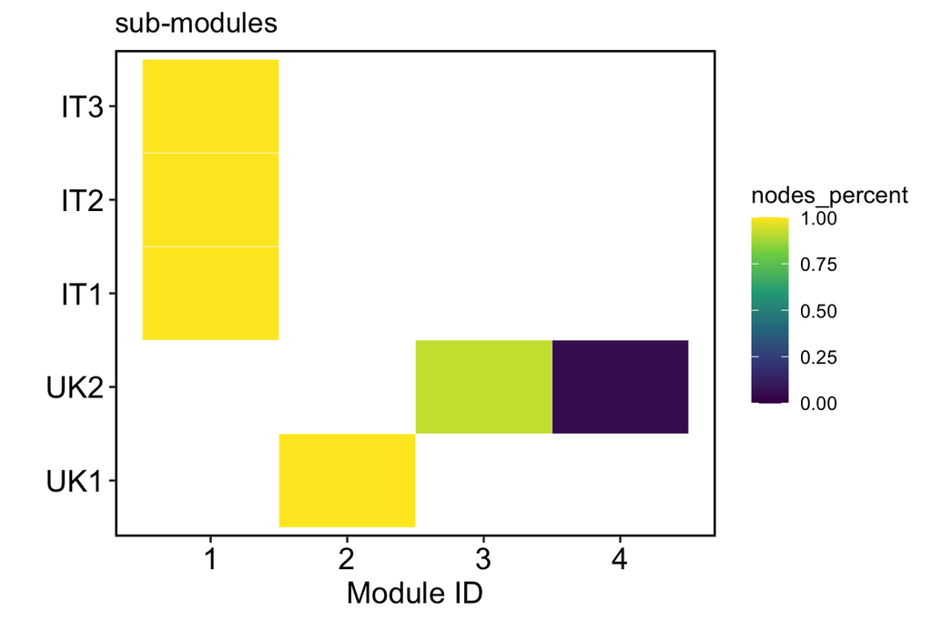

```r
sub_modules <-
modules_obs %>%
  mutate(short_name=factor(short_name, levels = c("UK1","UK2","IT1","IT2","IT3","FI1",'SE1'))) %>%
  # Filter out small modules as in the non-multilevel analysis.
  group_by(short_name) %>%
  mutate(nodes_in_layers=n_distinct(node_id)) %>%
  group_by(short_name,level1) %>%
  mutate(nodes_in_modules=n_distinct(node_id)) %>%
  mutate(nodes_percent=nodes_in_modules/nodes_in_layers) %>%
  filter(nodes_percent>=0.03) %>%
  # Now focus on the main module
  filter(level1==1) %>%
  # Recalculate the proportion of ASVs as: the number of ASVs in a sub-module in
  # a layer divided by the total number of ASVs included in the top module
  group_by(short_name) %>%
  mutate(nodes_in_layers=n_distinct(node_id)) %>%
  group_by(short_name,level2) %>%
  mutate(nodes_in_modules=n_distinct(node_id)) %>%
  mutate(nodes_percent=nodes_in_modules/nodes_in_layers) %>%
  distinct(short_name, level2, nodes_percent) %>%
  arrange(level2, short_name) %>%
  filter(nodes_percent>=0.03) %>%
  ggplot(aes(x = level2, y = short_name, fill=nodes_percent))+
    geom_tile(color='white')+
    scale_x_continuous(breaks = seq(1, max(modules_obs$level2), 1))+
    scale_fill_viridis_c(limits = c(0, 1))+
    labs(x='Module ID', y='', title='sub-modules')+
    paper_figs_theme

  sub_modules
```

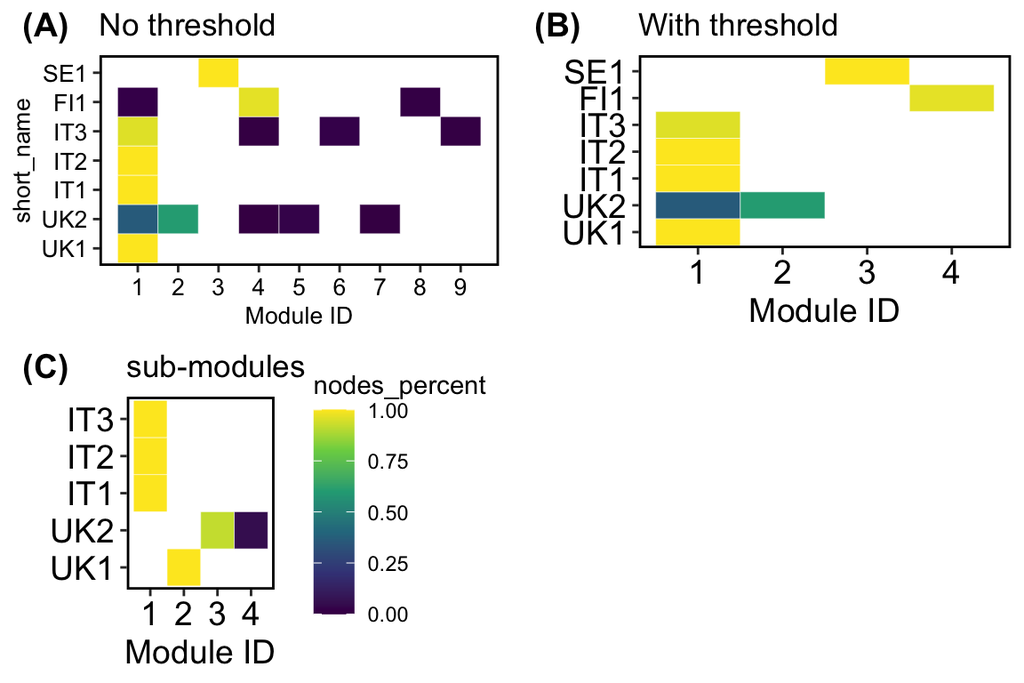

```r
modules_heir <- plot_grid(all_modules, filtered_modules+paper_figs_theme_no_legend, sub_modules, nrow = 2, ncol=2, rel_widths = c(0.5,0.5), labels = c('(A)','(B)','(C)'))

modules_heir
```

```r
# Make a file
pdf('~/Dropbox (BGU)/Apps/Overleaf/Rumen microbiome coocurrence/SI_modules_heir.pdf', 10, 6)
modules_heir
dev.off()
```

# Comparison to shuffled networks

### Fig. S8

The observed L value is smaller than that of all of the networks, resulting in a significant (P<0.002) differnece from random.

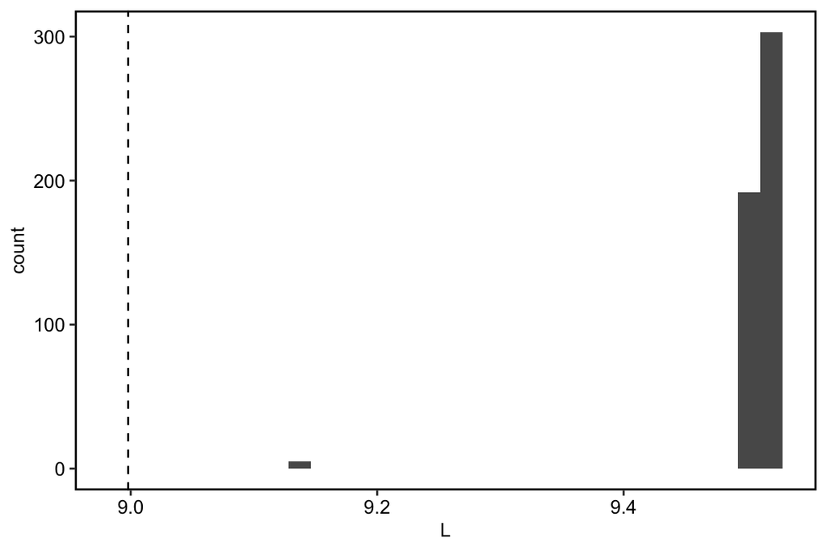

```r
parent.folder <- "HPC/shuffled/shuffle_farm_r0_30_shuff_500"
summ <- read_csv(paste(parent.folder,'/farm_modulation_summary_pf_unif.csv',sep=''), col_names = c('e_id','JOB','call','L','num_modules'))
summ %<>% slice(tail(row_number(), 1000)) %>% filter(!str_detect(call, '-2'))

L_obs_shuff <-
ggplot(summ, aes(L))+
  geom_histogram()+
  geom_vline(xintercept = L_obs, linetype='dashed')

L_obs_shuff+html_figs_theme_no_legend
```

### Fig. S9

In addition, the shuffled networks had only a single level and, except from a few instances, had a single module to which all farms belonged.

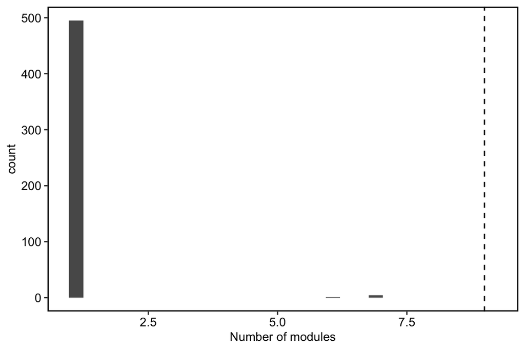

```r
num_modules_obs_shuff <-
ggplot(summ, aes(num_modules))+
  geom_histogram()+
  geom_vline(xintercept = num_modules_obs, linetype='dashed')+
  labs(x='Number of modules')
num_modules_obs_shuff+html_figs_theme_no_legend
```

```r
# Make a file
pdf('~/Dropbox (BGU)/Apps/Overleaf/Rumen microbiome coocurrence/SI_modularity_obs_shuff.pdf', 10, 6)
plot_grid(L_obs_shuff+paper_figs_theme_no_legend, num_modules_obs_shuff+paper_figs_theme_no_legend, ncol=2, rel_widths = c(0.5,0.5), labels = c('(A)','(B)'))
dev.off()
```